# ME - GIA. Binary (Model selection)

09 oct. 2024

# Introduction

The data (NLSAH) come from the survey of the National Longitudinal Study of Adolescent Health (Add Health), 1994-2008. This is a longitudinal study of a representative sample of adolescents in grades 7-12 in the United States during the 1994-1995 school year. The cohort was followed into adulthood with four home interviews, the most recent in 2008 when the participants were 24-32 years old. The data include social, economic, psychological, and physical health aspects of the respondents, along with contextual data about family, neighborhood, community, school, and friendships, providing a unique opportunity to study how social environments and behaviors in adolescence are linked to health and performance outcomes in adulthood. The goal is to build a binary response model to explain the positive response to the question of perceived health as Very Good or Excellent.

A total of **21** variables were selected from the 922 collected, and cases where any of these variables were missing were filtered. The total number of individuals is **3,950**.

- *sex*: Gender (*1-Male; 2-Female*)
- *age*: Age
- *race*: Race (*1-White; 2-Black; 3-Other*)
- *height*: Height (*cm*)
- *weight*: Weight (*kg*)
- *waist*: Waist circumference (*cm*)
- *SBP*: Systolic Blood Pressure (*mmHg*)
- *DBP*: Diastolic Blood Pressure (*mmHg*)
- *siblings*: Number of siblings
- *household*: Number of people in the household
- *income*: Total Annual Family Income (*1 - <25K; 2 - 25K-50K; 3 - 50K-75K; 4 - 75K-100K; 5 - >100K*)
- *insurance*: Has health insurance? (*0-no; 1-yes*)
- *arrested*: Has ever been arrested? (*0-no; 1-yes*)
- *sleep*: Has trouble sleeping? (*0-never; 1- <1 time/week; 2- 1 or 2 times/week; 3- >2 times/week*)
- *glasses*: Wears glasses or contact lenses? (*0-no; 1-yes*)
- *fastfood*: Number of times they ate fast food in the last 7 days
- *caffeine*: Consumed caffeine beverages in the last 24 hours? (*0-no; 1-yes*)
- *sugar*: Number of sugary drinks consumed in the last 7 days
- *cigars*: Number of cigarettes smoked daily in the last 30 days
- *TV*: Hours of TV watched in the last 7 days
- *Phealth*: (outcome): Perceived health (*0-Poor/Fair/Good; 1-Very Good/Excellent*)

```r
# Load packages
library(effects)
library(car)           # function Anova
library(emmeans)       # function emmeans
library(multcomp)      # function cld
library(multcompView)  # function cld
library(dplyr)         # data management
```

```r
# Read data
base <- read.csv2("../Dades/NLSAH.csv")
base <- base %>%
  mutate(across(c(sex, race, income, insurance, arrested,
                  sleep, glasses, caffeine), as.factor))
```

# Descriptive analysis

## Univariate exploratory data analysis

```r
summary(base)
```

```
##  sex           age        race         height          weight
##  1:1744   Min.   :25.00   1:2925   Min.   :122.5   Min.   : 38.80
##  2:2206   1st Qu.:28.00   2: 869   1st Qu.:162.5   1st Qu.: 67.20
##           Median :29.00   3: 156   Median :169.5   Median : 80.95
##           Mean   :29.04            Mean   :169.9   Mean   : 84.24
##           3rd Qu.:31.00            3rd Qu.:177.0   3rd Qu.: 97.00
##           Max.   :34.00            Max.   :204.0   Max.   :200.00
##      waist             SBP             DBP            siblings
##  Min.   : 50.00   Min.   : 77.0   Min.   : 31.00   Min.   : 0.000
##  1st Qu.: 86.00   1st Qu.:115.0   1st Qu.: 72.00   1st Qu.: 1.000
##  Median : 96.00   Median :123.0   Median : 78.50   Median : 2.000
##  Mean   : 98.43   Mean   :124.1   Mean   : 78.89   Mean   : 2.886
##  3rd Qu.:108.00   3rd Qu.:132.5   3rd Qu.: 85.00   3rd Qu.: 4.000
##  Max.   :194.00   Max.   :212.0   Max.   :145.00   Max.   :20.000
##    household      income   insurance arrested sleep    glasses
##  Min.   : 1.000   1: 591   0: 773    0:2855   0:1865   0:2107
##  1st Qu.: 1.000   2:1054   1:3177    1:1095   1: 757   1:1843
##  Median : 2.000   3:1001                      2: 699
##  Mean   : 2.429   4:1075                      3: 629
##  3rd Qu.: 3.000   5: 229
##  Max.   :15.000
##     fastfood      caffeine     sugar           cigars              TV
##  Min.   : 0.000   0:1157   Min.   : 0.00   Min.   :  0.000   Min.   :  0.00
##  1st Qu.: 1.000   1:2793   1st Qu.: 3.00   1st Qu.:  0.000   1st Qu.:  5.00
##  Median : 2.000            Median : 7.00   Median :  0.000   Median : 10.00
##  Mean   : 2.318            Mean   :11.98   Mean   :  3.775   Mean   : 13.65
##  3rd Qu.: 3.000            3rd Qu.:15.00   3rd Qu.:  4.000   3rd Qu.: 20.00
##  Max.   :35.000            Max.   :99.00   Max.   :100.000   Max.   :150.00
##     Phealth
##  Min.   :0.0000
##  1st Qu.:0.0000
##  Median :1.0000
##  Mean   :0.5711
##  3rd Qu.:1.0000
##  Max.   :1.0000
```

## Bivariate descriptive analysis

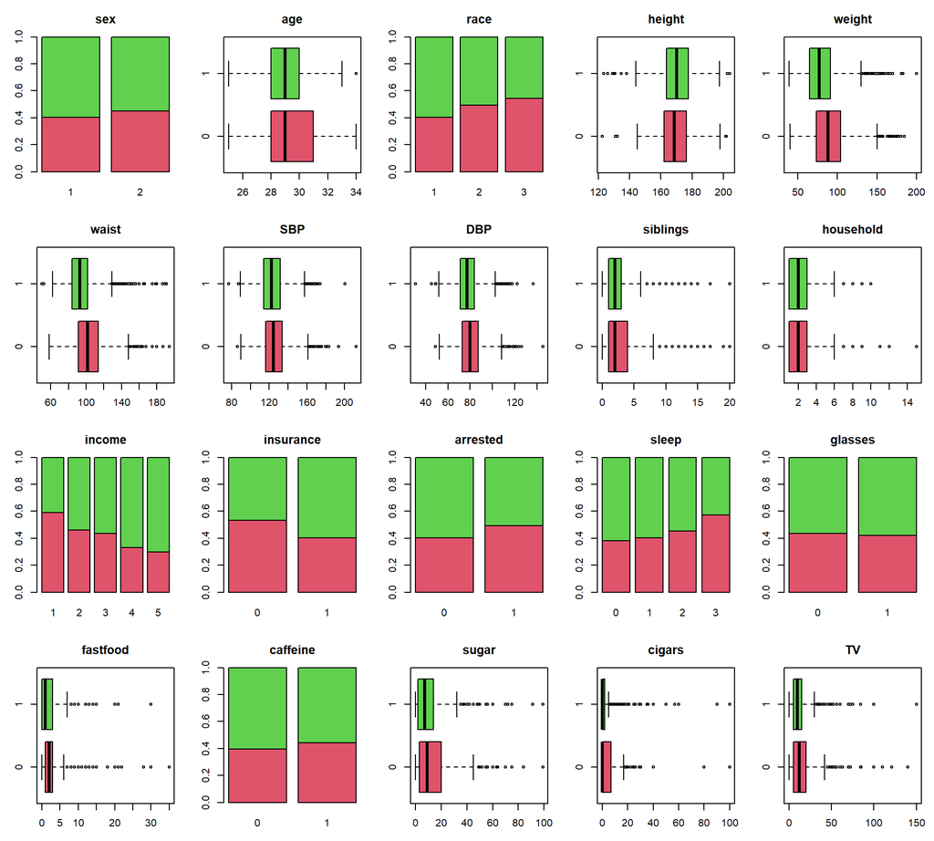

```r
vars <- colnames(base)[-21] # all variables except outcome: -21

par(mfrow=c(4,5), mar=c(3,3,3,1)) # 4x5 windows with margins 3,3,3,1
colors <- c(2,3)                  # colors: red (2) and green (3)

# Boxplot if numeric and barplot if categorical
for (v in vars){
  if (!is.factor(base[,v])){
    form <- as.formula(paste0(v,"~Phealth"))
    boxplot(form, base, main = v, col = colors, horizontal = TRUE)
  }else{
    tab <- prop.table(table(base$Phealth, base[,v]),2)
    barplot(tab, main = v, col = colors)
  }
}
```

# Variable selection (VS)

## VS using Deviance test

Deviance test using `Anova`function.

```r
# Full model
summary(m0 <- glm(Phealth ~ ., base, family=binomial(link='logit')))
```

```
##
## Call:
## glm(formula = Phealth ~ ., family = binomial(link = "logit"),
##     data = base)
##
## Coefficients:
##              Estimate Std. Error z value Pr(>|z|)
## (Intercept)  0.274478   1.162687   0.236 0.813377
## sex2        -0.193631   0.105366  -1.838 0.066108 .
## age         -0.019501   0.019926  -0.979 0.327728
## race2       -0.085255   0.090917  -0.938 0.348385
## race3       -0.725710   0.182786  -3.970 7.18e-05 ***
## height       0.025333   0.005228   4.846 1.26e-06 ***
## weight      -0.017426   0.003496  -4.984 6.22e-07 ***
## waist       -0.012639   0.004200  -3.009 0.002619 **
## SBP          0.008784   0.004481   1.960 0.049984 *
## DBP         -0.019361   0.005557  -3.484 0.000493 ***
## siblings    -0.047665   0.015559  -3.064 0.002187 **
## household   -0.066500   0.026257  -2.533 0.011319 *
## income2      0.348305   0.113557   3.067 0.002161 **
## income3      0.331873   0.117706   2.819 0.004810 **
## income4      0.619377   0.120815   5.127 2.95e-07 ***
## income5      0.746871   0.186773   3.999 6.37e-05 ***
## insurance1   0.207740   0.093136   2.230 0.025715 *
## arrested1   -0.259105   0.084274  -3.075 0.002108 **
## sleep1      -0.197096   0.095345  -2.067 0.038716 *
## sleep2      -0.307002   0.096560  -3.179 0.001476 **
## sleep3      -0.630073   0.102191  -6.166 7.02e-10 ***
## glasses1    -0.010471   0.072021  -0.145 0.884407
## fastfood    -0.028883   0.013159  -2.195 0.028166 *
## caffeine1   -0.103298   0.080250  -1.287 0.198026
## sugar       -0.001759   0.002687  -0.655 0.512714
## cigars      -0.022061   0.005316  -4.150 3.33e-05 ***
## TV          -0.010148   0.002745  -3.697 0.000218 ***
## ---
## Signif. codes:  0 '***' 0.001 '**' 0.01 '*' 0.05 '.' 0.1 ' ' 1
##
## (Dispersion parameter for binomial family taken to be 1)
##
##     Null deviance: 5395.6  on 3949  degrees of freedom
## Residual deviance: 4790.0  on 3923  degrees of freedom
## AIC: 4844
##
## Number of Fisher Scoring iterations: 4
```

**Interpretation of the coefficients**:

- Positive coefficients in a category of a **factor** indicate a higher probability of positive response compared to the reference and vice versa.
- Positive coefficients in a **covariate** indicate a higher probability of positive response with higher values and vice versa

The function `Anova` compares the full model with the full model without each variable using the Deviance test (=`LR`), i.e, for assess `sex`variable, the next two models are compared:

**M1**: `Y ~ age + race + height + weight + waist + SBP + DBP + siblings +` `household + income + insurance + arrested + sleep + glasses + fastfood +` `caffeine + sugar + cigars + TV + Phealth`

**M2**: `Y ~ age + race + height + weight + waist + SBP + DBP + siblings +` `household + income + insurance + arrested + sleep + glasses + fastfood +` `caffeine + sugar + cigars + TV + Phealth + sex`

```r
# Marginal contribution of each variable
Anova(m0, test.statistic = 'LR')
```

```
## Analysis of Deviance Table (Type II tests)
##
## Response: Phealth
##           LR Chisq Df Pr(>Chisq)
## sex          3.381  1  0.0659516 .
## age          0.958  1  0.3276272
## race        16.017  2  0.0003326 ***
## height      23.654  1  1.153e-06 ***
## weight      24.223  1  8.579e-07 ***
## waist        9.084  1  0.0025780 **
## SBP          3.854  1  0.0496368 *
## DBP         12.229  1  0.0004704 ***
## siblings     9.487  1  0.0020690 **
## household    6.433  1  0.0111992 *
## income      31.908  4  1.998e-06 ***
## insurance    4.967  1  0.0258322 *
## arrested     9.441  1  0.0021215 **
## sleep       40.567  3  8.078e-09 ***
## glasses      0.021  1  0.8844060
## fastfood     4.847  1  0.0277014 *
## caffeine     1.660  1  0.1975670
## sugar        0.429  1  0.5125698
## cigars      18.059  1  2.142e-05 ***
## TV          14.228  1  0.0001619 ***
## ---
## Signif. codes:  0 '***' 0.001 '**' 0.01 '*' 0.05 '.' 0.1 ' ' 1
```

**Most variables are significant. We could keep in the model all variables that are significant**. However is a best option to remove variables one by one.

```r
summary(m0.1 <- glm(Phealth ~ race + height + weight + waist + SBP + DBP +
                              siblings + household + income + insurance + arrested +
                              sleep + fastfood + cigars + TV,
                    base, family=binomial(link='logit')))
```

```
##
## Call:
## glm(formula = Phealth ~ race + height + weight + waist + SBP +
##     DBP + siblings + household + income + insurance + arrested +
##     sleep + fastfood + cigars + TV, family = binomial(link = "logit"),
##     data = base)
##
## Coefficients:
##              Estimate Std. Error z value Pr(>|z|)
## (Intercept) -1.416376   0.818896  -1.730 0.083699 .
## race2       -0.077850   0.089466  -0.870 0.384210
## race3       -0.678673   0.181219  -3.745 0.000180 ***
## height       0.030553   0.004395   6.952 3.61e-12 ***
## weight      -0.016825   0.003474  -4.843 1.28e-06 ***
## waist       -0.013726   0.004152  -3.306 0.000948 ***
## SBP          0.010337   0.004392   2.354 0.018596 *
## DBP         -0.020490   0.005518  -3.713 0.000205 ***
## siblings    -0.047942   0.015514  -3.090 0.002000 **
## household   -0.071999   0.025963  -2.773 0.005552 **
## income2      0.359047   0.113126   3.174 0.001504 **
## income3      0.341612   0.117156   2.916 0.003547 **
## income4      0.634220   0.119696   5.299 1.17e-07 ***
## income5      0.771314   0.185790   4.152 3.30e-05 ***
## insurance1   0.192233   0.092635   2.075 0.037971 *
## arrested1   -0.231738   0.082581  -2.806 0.005013 **
## sleep1      -0.209292   0.095061  -2.202 0.027690 *
## sleep2      -0.318002   0.096358  -3.300 0.000966 ***
## sleep3      -0.647054   0.101711  -6.362 2.00e-10 ***
## fastfood    -0.029409   0.012881  -2.283 0.022421 *
## cigars      -0.023366   0.005202  -4.492 7.06e-06 ***
## TV          -0.010056   0.002730  -3.684 0.000230 ***
## ---
## Signif. codes:  0 '***' 0.001 '**' 0.01 '*' 0.05 '.' 0.1 ' ' 1
##
## (Dispersion parameter for binomial family taken to be 1)
##
##     Null deviance: 5395.6  on 3949  degrees of freedom
## Residual deviance: 4796.7  on 3928  degrees of freedom
## AIC: 4840.7
##
## Number of Fisher Scoring iterations: 4
```

```r
# Marginal contribution of each variable
Anova(m0.1, test.statistic = 'LR')
```

```
## Analysis of Deviance Table (Type II tests)
##
## Response: Phealth
##           LR Chisq Df Pr(>Chisq)
## race        14.218  2  0.0008176 ***
## height      49.174  1  2.342e-12 ***
## weight      22.871  1  1.732e-06 ***
## waist       10.986  1  0.0009181 ***
## SBP          5.564  1  0.0183372 *
## DBP         13.899  1  0.0001929 ***
## siblings     9.662  1  0.0018812 **
## household    7.721  1  0.0054576 **
## income      34.259  4  6.593e-07 ***
## insurance    4.299  1  0.0381316 *
## arrested     7.857  1  0.0050620 **
## sleep       43.339  3  2.085e-09 ***
## fastfood     5.245  1  0.0220128 *
## cigars      21.177  1  4.187e-06 ***
## TV          14.116  1  0.0001719 ***
## ---
## Signif. codes:  0 '***' 0.001 '**' 0.01 '*' 0.05 '.' 0.1 ' ' 1
```

## VS using AIC/BIC

We can perform automatic variable selection using the `step` function and **BIC** criterion. We will compare with the previous model.

*We can use automatic selection because there are no missing values in the data. We use BIC because it penalizes the addition of more parameters to the model, which is desirable since we have many covariates*

```r
m0.2 <- step(m0, direction="both",
             k = log(nrow(base)),
             trace = FALSE)
summary(m0.2)
```

```
##
## Call:
## glm(formula = Phealth ~ height + weight + waist + DBP + siblings +
##     household + income + arrested + sleep + cigars + TV, family = binomial(link = "logit"),
##     data = base)
##
## Coefficients:
##              Estimate Std. Error z value Pr(>|z|)
## (Intercept) -1.171145   0.797830  -1.468 0.142128
## height       0.032329   0.004321   7.482 7.30e-14 ***
## weight      -0.016246   0.003395  -4.785 1.71e-06 ***
## waist       -0.012880   0.004102  -3.140 0.001692 **
## DBP         -0.011833   0.003609  -3.278 0.001044 **
## siblings    -0.051384   0.015295  -3.359 0.000781 ***
## household   -0.086696   0.025646  -3.381 0.000723 ***
## income2      0.383501   0.111672   3.434 0.000594 ***
## income3      0.389207   0.113843   3.419 0.000629 ***
## income4      0.685757   0.114961   5.965 2.44e-09 ***
## income5      0.800051   0.181187   4.416 1.01e-05 ***
## arrested1   -0.264435   0.081333  -3.251 0.001149 **
## sleep1      -0.205059   0.094404  -2.172 0.029845 *
## sleep2      -0.322685   0.095858  -3.366 0.000762 ***
## sleep3      -0.656417   0.101051  -6.496 8.25e-11 ***
## cigars      -0.022907   0.005084  -4.505 6.62e-06 ***
## TV          -0.011334   0.002719  -4.168 3.07e-05 ***
## ---
## Signif. codes:  0 '***' 0.001 '**' 0.01 '*' 0.05 '.' 0.1 ' ' 1
##
## (Dispersion parameter for binomial family taken to be 1)
##
##     Null deviance: 5395.6  on 3949  degrees of freedom
## Residual deviance: 4825.5  on 3933  degrees of freedom
## AIC: 4859.5
##
## Number of Fisher Scoring iterations: 4
```

```r
cat('no. coefficients m0.1:', length(coef(m0.1)),'\n')
```

```
## no. coefficients m0.1: 22
```

```r
cat('no. coefficients m0.2:', length(coef(m0.2)),'\n')
```

```
## no. coefficients m0.2: 17
```

We can compare the two initial models with a deviance test because they are nested models. `m0.1` model improves the `m0.2` model. We select **`m0.1`** model.

```r
anova(m0.2, m0.1, test = 'Chisq')
```

```
## Analysis of Deviance Table
##
## Model 1: Phealth ~ height + weight + waist + DBP + siblings + household +
##     income + arrested + sleep + cigars + TV
## Model 2: Phealth ~ race + height + weight + waist + SBP + DBP + siblings +
##     household + income + insurance + arrested + sleep + fastfood +
##     cigars + TV
##   Resid. Df Resid. Dev Df Deviance  Pr(>Chi)
## 1      3933     4825.5
## 2      3928     4796.7  5   28.765 2.578e-05 ***
## ---
## Signif. codes:  0 '***' 0.001 '**' 0.01 '*' 0.05 '.' 0.1 ' ' 1
```

## Validation

Standard model diagnostics using `residualPlots`

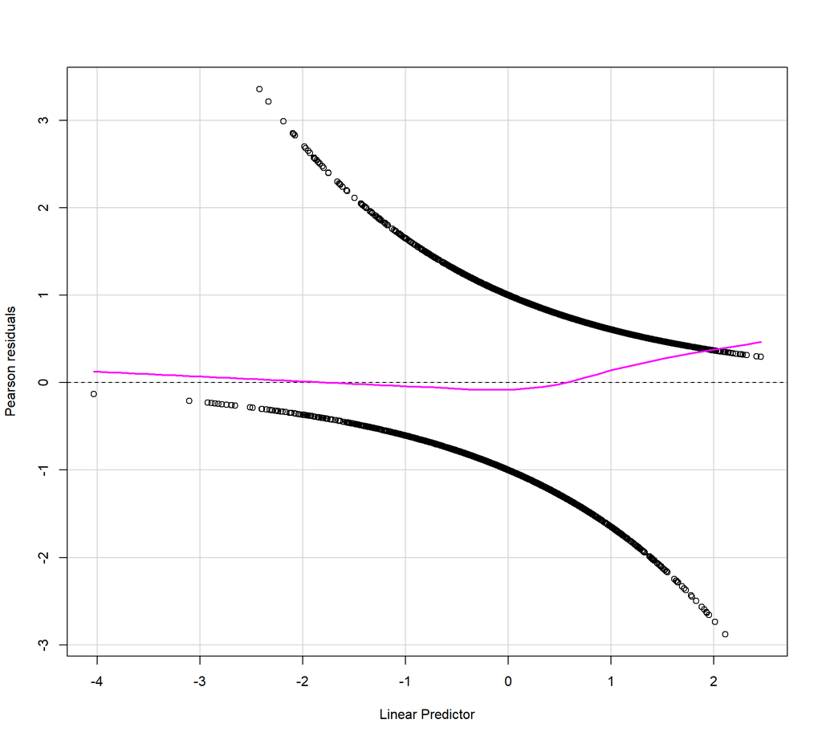

```r
residualPlot (m0.1)
```

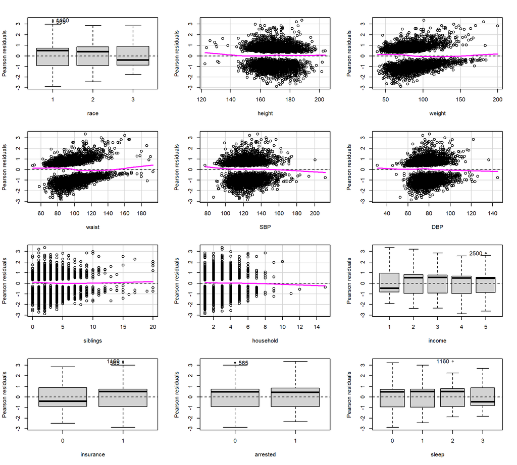

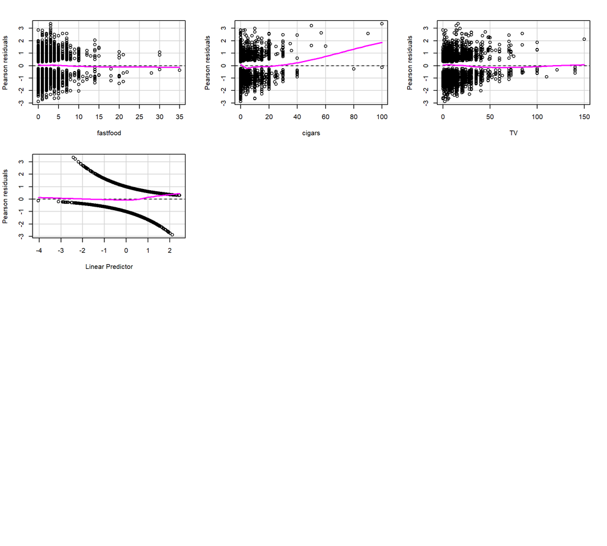

```r
residualPlots(m0.1, layout = c(4,3), ask = FALSE, tests = FALSE)
```

*The obtained model is quite good, but we will try to improve it.*

# Improve the model: *waist*

## Aggregation

We did an aggregation using variable **`waist`**

```r
dfbase <- with(base,aggregate(x   = cbind(ypos = Phealth, yneg = 1 - Phealth),
                              by  = list(waist=waist),
                              FUN = sum))
```

## Simple Model

Model with variable *waist* using aggregate data:

```r
m_waist <- glm(cbind(ypos,yneg) ~ waist, data=dfbase,
               family=binomial(link='logit'))
summary(m_waist)
```

```
##
## Call:
## glm(formula = cbind(ypos, yneg) ~ waist, family = binomial(link = "logit"),
##     data = dfbase)
##
## Coefficients:
##              Estimate Std. Error z value Pr(>|z|)
## (Intercept)  3.421801   0.209397   16.34   <2e-16 ***
## waist       -0.031755   0.002093  -15.17   <2e-16 ***
## ---
## Signif. codes:  0 '***' 0.001 '**' 0.01 '*' 0.05 '.' 0.1 ' ' 1
##
## (Dispersion parameter for binomial family taken to be 1)
##
##     Null deviance: 526.34  on 198  degrees of freedom
## Residual deviance: 268.43  on 197  degrees of freedom
## AIC: 696.29
##
## Number of Fisher Scoring iterations: 4
```

### Validation

We use **`residualPlots`**

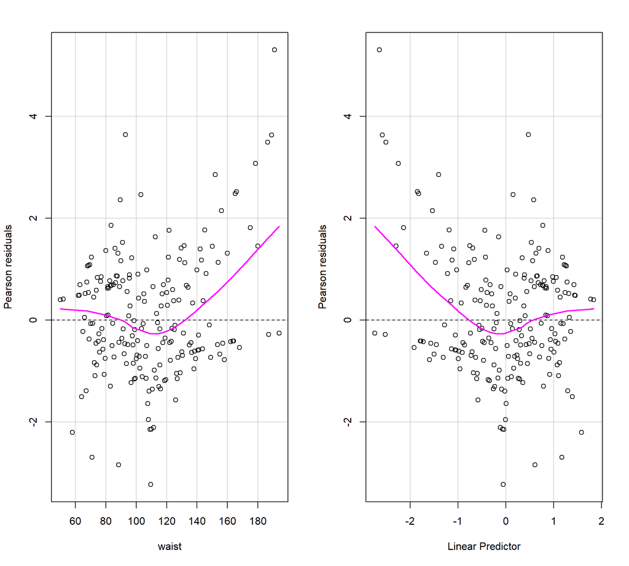

```
##       Test stat Pr(>|Test stat|)
## waist    18.591         1.62e-05 ***
## ---
## Signif. codes:  0 '***' 0.001 '**' 0.01 '*' 0.05 '.' 0.1 ' ' 1
```

```r
residualPlots(m_waist)
```

*The test indicates that the presence of a quadratic term is necessary*

## Model with polynomial terms

We fit the models up to order 4 and compare them using the deviance test, AIC, and BIC.

```r
m_waist.1 <- glm(cbind(ypos,yneg) ~ waist,        data = dfbase, family=binomial)
m_waist.2 <- glm(cbind(ypos,yneg) ~ poly(waist,2),data = dfbase, family=binomial)
m_waist.3 <- glm(cbind(ypos,yneg) ~ poly(waist,3),data = dfbase, family=binomial)
m_waist.4 <- glm(cbind(ypos,yneg) ~ poly(waist,4),data = dfbase, family=binomial)

# Deviance test
anova(m_waist.1, m_waist.2, test="Chisq")
```

```
## Analysis of Deviance Table
##
## Model 1: cbind(ypos, yneg) ~ waist
## Model 2: cbind(ypos, yneg) ~ poly(waist, 2)
##   Resid. Df Resid. Dev Df Deviance Pr(>Chi)
## 1       197     268.43
## 2       196     249.84  1   18.591 1.62e-05 ***
## ---
## Signif. codes:  0 '***' 0.001 '**' 0.01 '*' 0.05 '.' 0.1 ' ' 1
```

```r
anova(m_waist.2, m_waist.3, test="Chisq")
```

```
## Analysis of Deviance Table
##
## Model 1: cbind(ypos, yneg) ~ poly(waist, 2)
## Model 2: cbind(ypos, yneg) ~ poly(waist, 3)
##   Resid. Df Resid. Dev Df Deviance  Pr(>Chi)
## 1       196     249.84
## 2       195     235.12  1   14.728 0.0001242 ***
## ---
## Signif. codes:  0 '***' 0.001 '**' 0.01 '*' 0.05 '.' 0.1 ' ' 1
```

```r
anova(m_waist.3, m_waist.4, test="Chisq")
```

```
## Analysis of Deviance Table
##
## Model 1: cbind(ypos, yneg) ~ poly(waist, 3)
## Model 2: cbind(ypos, yneg) ~ poly(waist, 4)
##   Resid. Df Resid. Dev Df Deviance Pr(>Chi)
## 1       195     235.12
## 2       194     230.59  1   4.5231  0.03344 *
## ---
## Signif. codes:  0 '***' 0.001 '**' 0.01 '*' 0.05 '.' 0.1 ' ' 1
```

```r
# AIC and BIC
cbind(      AIC(m_waist.1, m_waist.2, m_waist.3, m_waist.4),
      BIC = BIC(m_waist.1, m_waist.2, m_waist.3, m_waist.4)[,2])
```

```
##           df      AIC      BIC
## m_waist.1  2 696.2941 702.8807
## m_waist.2  3 679.7033 689.5832
## m_waist.3  4 666.9756 680.1488
## m_waist.4  5 664.4525 680.9190
```

*According to deviance and AIC, we would choose the 4th-order polynomial. According to BIC, the 3rd-order polynomial*

### Validation

We check 3rd and 4th order polynomial

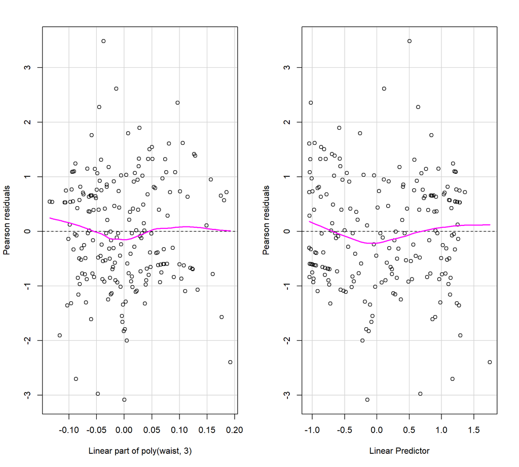

```r
residualPlots(m_waist.3, layout=c(1, 2))
```

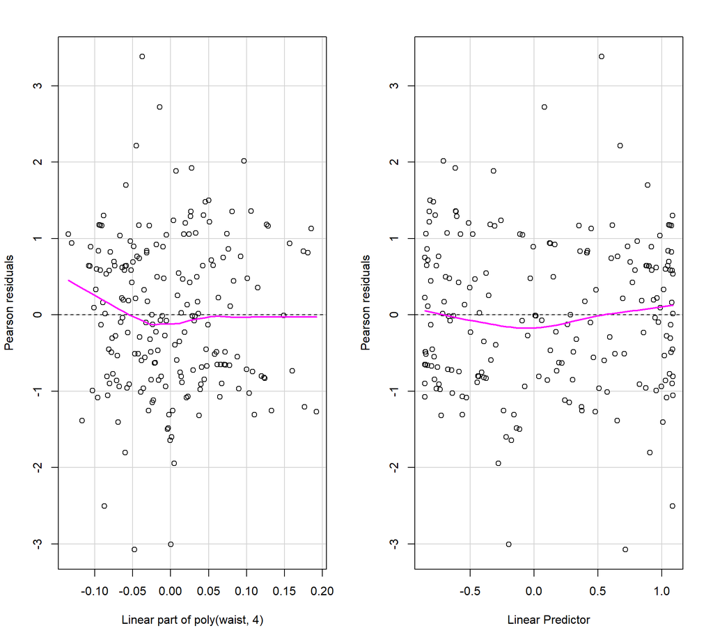

```r
residualPlots(m_waist.4, layout=c(1, 2))
```

## Model with 2 slopes

We fit a model with two slopes

*We are testing this model because the graph gives the impression that this pattern exists. The model provides a better BIC compared to the previous models*

```r
dfbase$Iwaist = as.factor(ifelse(dfbase$waist<=105,0,1))
summary(dfbase$Iwaist)
```

```
##   0   1
##  98 101
```

```r
##-- Interaction with waist (two slopes?)
m_waist.5 <- glm(cbind(ypos, yneg) ~ waist * Iwaist,
                 data = dfbase, family = binomial)
m_waist.6 <- glm(cbind(ypos, yneg) ~ Iwaist + waist:Iwaist + poly(waist,4),
                 data = dfbase, family = binomial)

anova(m_waist.1, m_waist.5,test='Chisq')
```

```
## Analysis of Deviance Table
##
## Model 1: cbind(ypos, yneg) ~ waist
## Model 2: cbind(ypos, yneg) ~ waist * Iwaist
##   Resid. Df Resid. Dev Df Deviance  Pr(>Chi)
## 1       197     268.43
## 2       195     231.65  2   36.788 1.027e-08 ***
## ---
## Signif. codes:  0 '***' 0.001 '**' 0.01 '*' 0.05 '.' 0.1 ' ' 1
```

```r
anova(m_waist.5, m_waist.6,test='Chisq')
```

```
## Analysis of Deviance Table
##
## Model 1: cbind(ypos, yneg) ~ waist * Iwaist
## Model 2: cbind(ypos, yneg) ~ Iwaist + waist:Iwaist + poly(waist, 4)
##   Resid. Df Resid. Dev Df Deviance Pr(>Chi)
## 1       195     231.65
## 2       192     221.99  3   9.6588   0.0217 *
## ---
## Signif. codes:  0 '***' 0.001 '**' 0.01 '*' 0.05 '.' 0.1 ' ' 1
```

```r
cbind(AIC = AIC(m_waist.3, m_waist.4, m_waist.5, m_waist.6),
      BIC = BIC(m_waist.3, m_waist.4, m_waist.5, m_waist.6)[,2])
```

```
##           AIC.df  AIC.AIC      BIC
## m_waist.3      4 666.9756 680.1488
## m_waist.4      5 664.4525 680.9190
## m_waist.5      4 663.5057 676.6789
## m_waist.6      7 659.8469 682.9000
```

### Validation

Best diagnosis

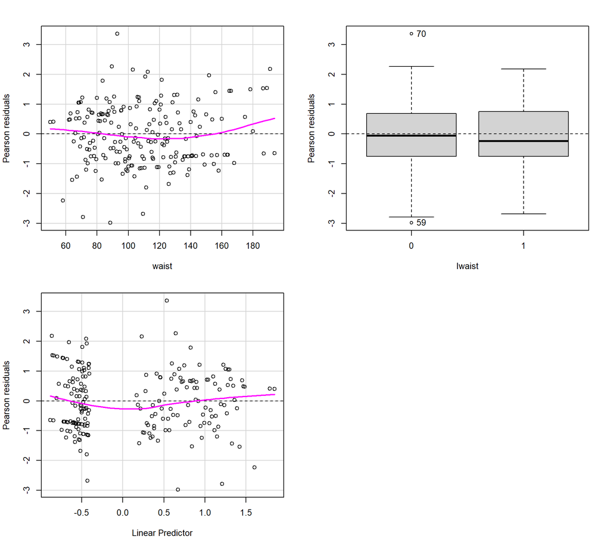

```
##        Test stat Pr(>|Test stat|)
## waist     1.4961           0.2213
## Iwaist
```

```r
residualPlots(m_waist.5)
```

Effect using `allEffects` to see the two slopes

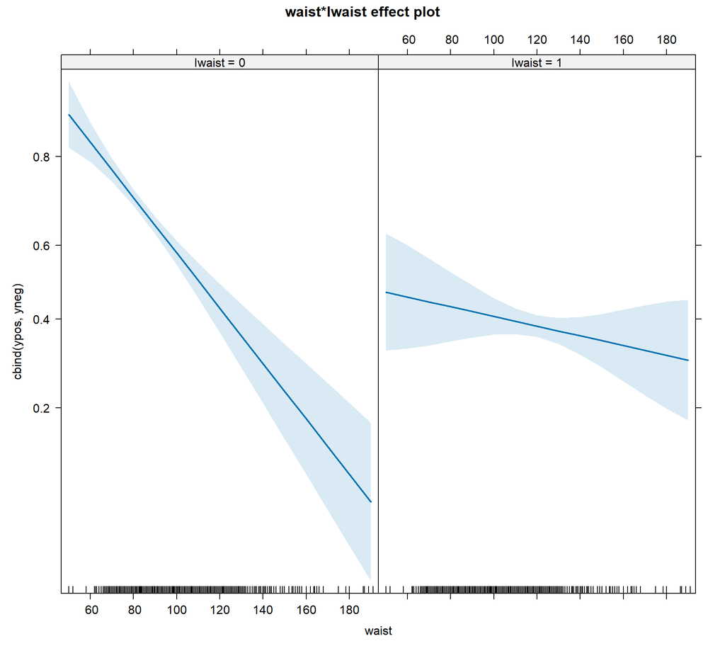

```r
plot(allEffects(m_waist.5))
```

## Full model including waist with 2 slopes

```r
base$Iwaist = as.factor(ifelse(base$waist<=105,0,1))

m1 <- update(m0.1, . ~ . + Iwaist + waist:Iwaist)
```

### Validation

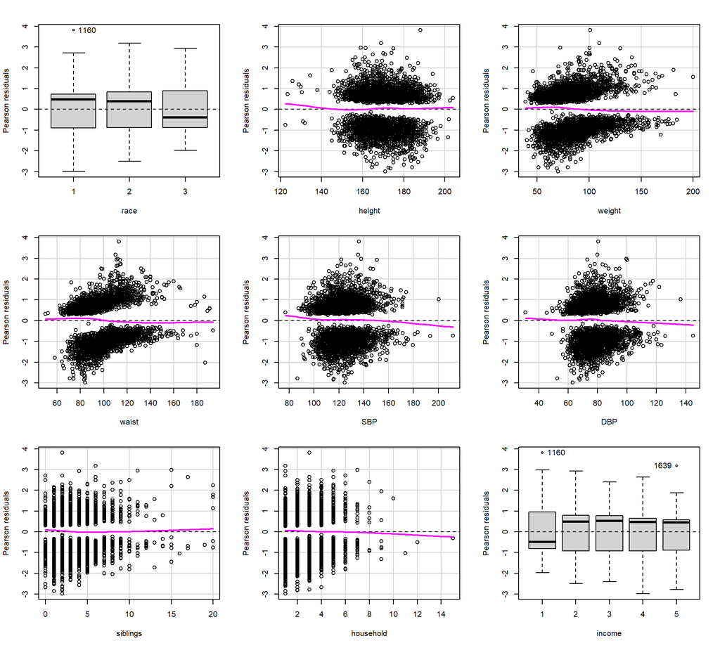

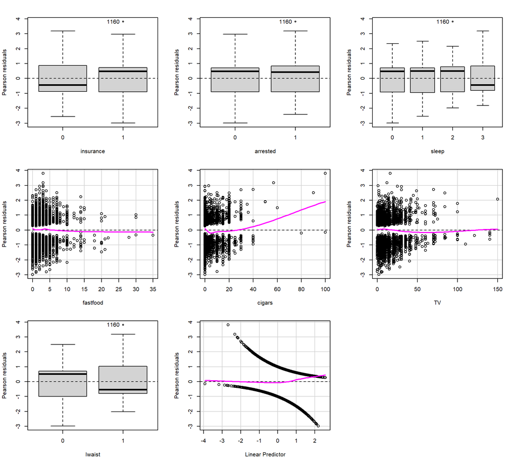

```
##           Test stat Pr(>|Test stat|)
## race
## height       0.4302          0.51187
## weight       0.0148          0.90309
## waist        0.0503          0.82258
## SBP          0.2769          0.59871
## DBP          0.5543          0.45658
## siblings     3.4294          0.06404 .
## household    0.0064          0.93604
## income
## insurance
## arrested
## sleep
## fastfood     0.0089          0.92471
## cigars      19.7130        8.999e-06 ***
## TV           1.7954          0.18027
## Iwaist
## ---
## Signif. codes:  0 '***' 0.001 '**' 0.01 '*' 0.05 '.' 0.1 ' ' 1
```

```r
residualPlots(m1)
```

# Improve the model: cigars

## Aggregation

We did an aggregation using variable **`cigars`**

```r
dfbase1 <- with(base,aggregate(cbind(ypos = Phealth, yneg = 1-Phealth),
                               list(cigars=cigars),
                               sum))
```

## Simple Model

Model with variable *cigars* using aggregate data:

```r
m_cigars <- glm(cbind(ypos,yneg) ~ cigars, data=dfbase1, family=binomial(link='logit'))
summary(m_cigars)
```

```
##
## Call:
## glm(formula = cbind(ypos, yneg) ~ cigars, family = binomial(link = "logit"),
##     data = dfbase1)
##
## Coefficients:
##              Estimate Std. Error z value Pr(>|z|)
## (Intercept)  0.406552   0.036604  11.107  < 2e-16 ***
## cigars      -0.031628   0.004572  -6.917 4.61e-12 ***
## ---
## Signif. codes:  0 '***' 0.001 '**' 0.01 '*' 0.05 '.' 0.1 ' ' 1
##
## (Dispersion parameter for binomial family taken to be 1)
##
##     Null deviance: 158.26  on 36  degrees of freedom
## Residual deviance: 106.79  on 35  degrees of freedom
## AIC: 206.38
##
## Number of Fisher Scoring iterations: 4
```

### Validation

We use **`residualPlots`**

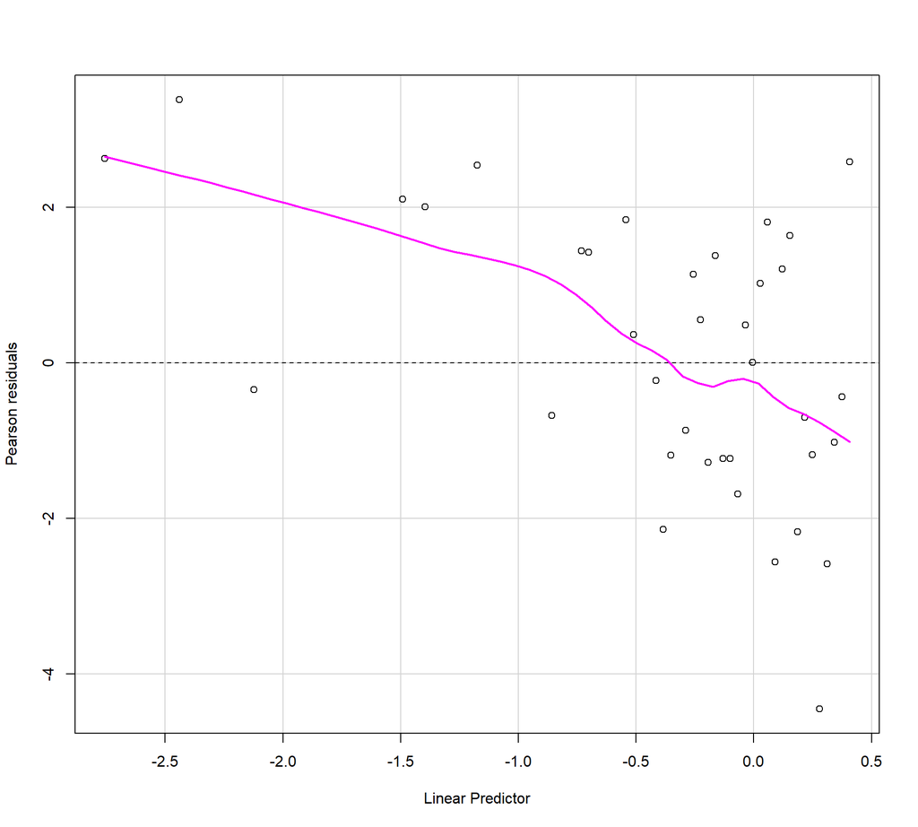

```r
residualPlot(m_cigars)
```

## Models with polynomial terms

We fit the models up to order 4 and compare them using the deviance test, AIC, and BIC.

```r
m_cigars.1 <- glm(cbind(ypos,yneg) ~ cigars,        data=dfbase1,family=binomial)
m_cigars.2 <- glm(cbind(ypos,yneg) ~ poly(cigars,2),data=dfbase1,family=binomial)
m_cigars.3 <- glm(cbind(ypos,yneg) ~ poly(cigars,3),data=dfbase1,family=binomial)
m_cigars.4 <- glm(cbind(ypos,yneg) ~ poly(cigars,4),data=dfbase1,family=binomial)

# Deviance test
anova(m_cigars.1, m_cigars.2, test="Chisq")
```

```
## Analysis of Deviance Table
##
## Model 1: cbind(ypos, yneg) ~ cigars
## Model 2: cbind(ypos, yneg) ~ poly(cigars, 2)
##   Resid. Df Resid. Dev Df Deviance  Pr(>Chi)
## 1        35    106.793
## 2        34     88.307  1   18.487 1.711e-05 ***
## ---
## Signif. codes:  0 '***' 0.001 '**' 0.01 '*' 0.05 '.' 0.1 ' ' 1
```

```r
anova(m_cigars.2, m_cigars.3, test="Chisq")
```

```
## Analysis of Deviance Table
##
## Model 1: cbind(ypos, yneg) ~ poly(cigars, 2)
## Model 2: cbind(ypos, yneg) ~ poly(cigars, 3)
##   Resid. Df Resid. Dev Df Deviance  Pr(>Chi)
## 1        34     88.307
## 2        33     76.312  1   11.994 0.0005336 ***
## ---
## Signif. codes:  0 '***' 0.001 '**' 0.01 '*' 0.05 '.' 0.1 ' ' 1
```

```r
anova(m_cigars.3, m_cigars.4, test="Chisq")
```

```
## Analysis of Deviance Table
##
## Model 1: cbind(ypos, yneg) ~ poly(cigars, 3)
## Model 2: cbind(ypos, yneg) ~ poly(cigars, 4)
##   Resid. Df Resid. Dev Df Deviance Pr(>Chi)
## 1        33     76.312
## 2        32     73.820  1   2.4918   0.1144
```

```r
# AIC and BIC
cbind(      AIC(m_cigars.1,m_cigars.2,m_cigars.3,m_cigars.4),
      BIC = BIC(m_cigars.1,m_cigars.2,m_cigars.3,m_cigars.4)[,2])
```

```
##            df      AIC      BIC
## m_cigars.1  2 206.3801 209.6019
## m_cigars.2  3 189.8932 194.7260
## m_cigars.3  4 179.8989 186.3426
## m_cigars.4  5 179.4071 187.4617
```

### Validation

We check 3rd and 4th order polynomial

```r
summary(m_cigars.3)
```

```
##
## Call:
## glm(formula = cbind(ypos, yneg) ~ poly(cigars, 3), family = binomial,
##     data = dfbase1)
##
## Coefficients:
##                  Estimate Std. Error z value Pr(>|z|)
## (Intercept)       0.04998    0.12641   0.395 0.692544
## poly(cigars, 3)1  1.40881    1.44600   0.974 0.329918
## poly(cigars, 3)2  0.09598    1.02439   0.094 0.925349
## poly(cigars, 3)3 -2.45847    0.71220  -3.452 0.000557 ***
## ---
## Signif. codes:  0 '***' 0.001 '**' 0.01 '*' 0.05 '.' 0.1 ' ' 1
##
## (Dispersion parameter for binomial family taken to be 1)
##
##     Null deviance: 158.264  on 36  degrees of freedom
## Residual deviance:  76.312  on 33  degrees of freedom
## AIC: 179.9
##
## Number of Fisher Scoring iterations: 4
```

```r
summary(m_cigars.4)
```

```
##
## Call:
## glm(formula = cbind(ypos, yneg) ~ poly(cigars, 4), family = binomial,
##     data = dfbase1)
##
## Coefficients:
##                  Estimate Std. Error z value Pr(>|z|)
## (Intercept)      -0.04624    0.13342  -0.347    0.729
## poly(cigars, 4)1  0.42212    1.50069   0.281    0.778
## poly(cigars, 4)2  0.33452    1.03551   0.323    0.747
## poly(cigars, 4)3 -0.75008    1.27265  -0.589    0.556
## poly(cigars, 4)4  1.21094    0.76033   1.593    0.111
##
## (Dispersion parameter for binomial family taken to be 1)
##
##     Null deviance: 158.26  on 36  degrees of freedom
## Residual deviance:  73.82  on 32  degrees of freedom
## AIC: 179.41
##
## Number of Fisher Scoring iterations: 4
```

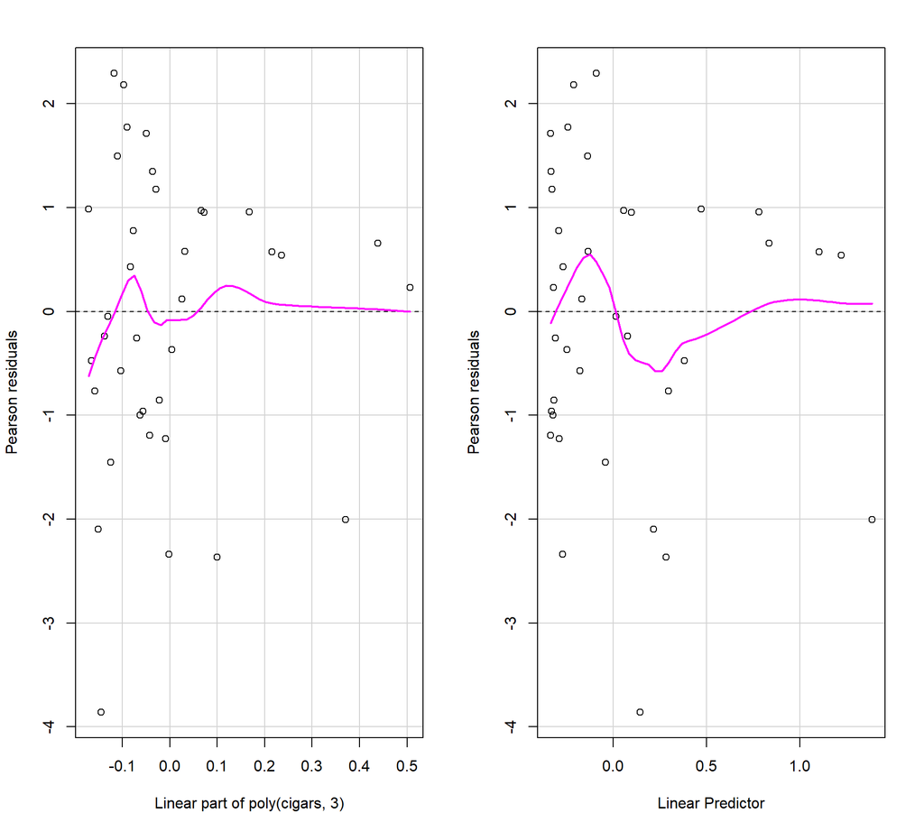

```r
residualPlots(m_cigars.3, layout = c(1, 2))
```

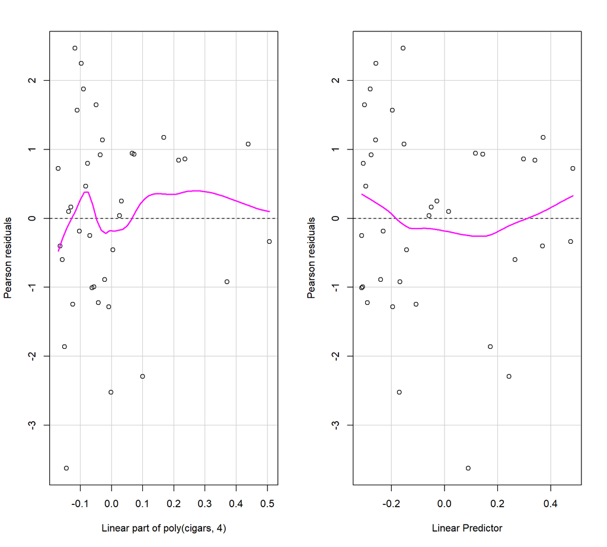

```r
residualPlots(m_cigars.4, layout = c(1, 2))
```

## Full model including cigars with polynomial term

```r
m2 <- update(m0.1, . ~ . + Iwaist + waist:Iwaist - cigars + poly(cigars,4))
```

### Validation

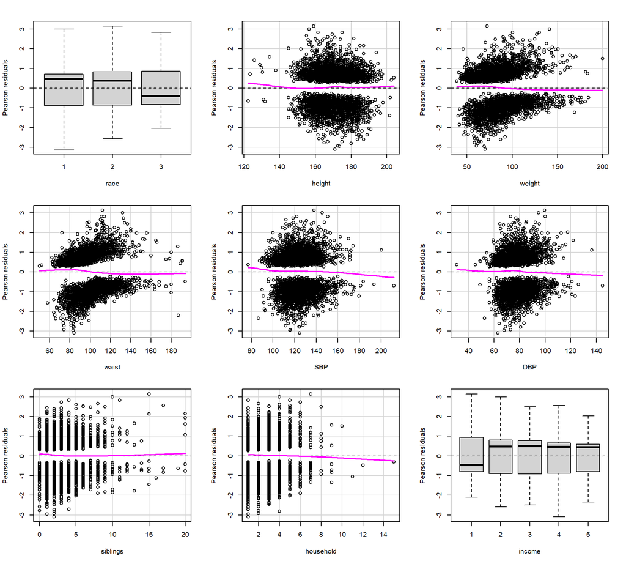

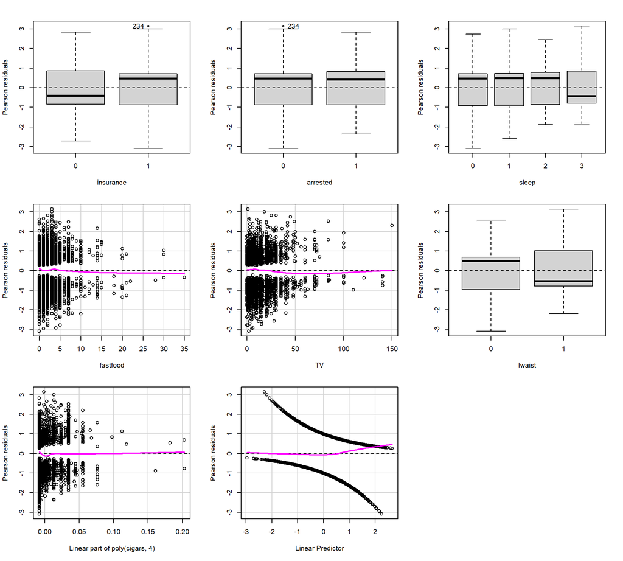

```
##                 Test stat Pr(>|Test stat|)
## race
## height             0.4436          0.50537
## weight             0.0121          0.91231
## waist              0.0585          0.80891
## SBP                0.1496          0.69892
## DBP                0.2398          0.62433
## siblings           3.1985          0.07371 .
## household          0.0047          0.94544
## income
## insurance
## arrested
## sleep
## fastfood           0.0000          0.99824
## TV                 1.0702          0.30089
## Iwaist
## poly(cigars, 4)
## ---
## Signif. codes:  0 '***' 0.001 '**' 0.01 '*' 0.05 '.' 0.1 ' ' 1
```

```r
residualPlots(m2)
```